# Final project2

Yuchen li

2025-02-21

# This analysis explores the key factors influencing diabetes using the Pima Indians Diabetes Dataset.

# We examine correlations between glucose, BMI, blood pressure, insulin, age, and diabetes outcomes

# to identify significant risk factors and visualize their relationships.

## Data description

```r
file_path <- "/Users/Brian/Desktop/final/data/diabetes.csv"
diabetes <- read.csv(file_path)

# Data pre-processing

diabetes$BMI[diabetes$BMI == 0] <- NA
diabetes$Glucose[diabetes$Glucose == 0] <- NA
diabetes$BloodPressure[diabetes$BloodPressure == 0] <- NA

clean_diabetes <- diabetes %>%
  filter(!is.na(Glucose)) %>%
  filter(!is.na(BloodPressure)) %>%
  filter(!is.na(BMI))

str(diabetes)
```

```
## 'data.frame':    768 obs. of  9 variables:
##  $ Pregnancies             : int  6 1 8 1 0 5 3 10 2 8 ...
##  $ Glucose                 : int  148 85 183 89 137 116 78 115 197 125 ...
##  $ BloodPressure           : int  72 66 64 66 40 74 50 NA 70 96 ...
##  $ SkinThickness           : int  35 29 0 23 35 0 32 0 45 0 ...
##  $ Insulin                 : int  0 0 0 94 168 0 88 0 543 0 ...
##  $ BMI                     : num  33.6 26.6 23.3 28.1 43.1 25.6 31 35.3 30.5 NA ...
##  $ DiabetesPedigreeFunction: num  0.627 0.351 0.672 0.167 2.288 ...
##  $ Age                     : int  50 31 32 21 33 30 26 29 53 54 ...
##  $ Outcome                 : int  1 0 1 0 1 0 1 0 1 1 ...
```

```r
dim(diabetes)
```

```
## [1] 768   9
```

```r
summary(diabetes)
```

```
##   Pregnancies        Glucose      BloodPressure    SkinThickness
##  Min.   : 0.000   Min.   : 44.0   Min.   : 24.00   Min.   : 0.00
##  1st Qu.: 1.000   1st Qu.: 99.0   1st Qu.: 64.00   1st Qu.: 0.00
##  Median : 3.000   Median :117.0   Median : 72.00   Median :23.00
##  Mean   : 3.845   Mean   :121.7   Mean   : 72.41   Mean   :20.54
##  3rd Qu.: 6.000   3rd Qu.:141.0   3rd Qu.: 80.00   3rd Qu.:32.00
##  Max.   :17.000   Max.   :199.0   Max.   :122.00   Max.   :99.00
##                   NA's   :5       NA's   :35
##     Insulin           BMI        DiabetesPedigreeFunction      Age
##  Min.   :  0.0   Min.   :18.20   Min.   :0.0780           Min.   :21.00
##  1st Qu.:  0.0   1st Qu.:27.50   1st Qu.:0.2437           1st Qu.:24.00
##  Median : 30.5   Median :32.30   Median :0.3725           Median :29.00
##  Mean   : 79.8   Mean   :32.46   Mean   :0.4719           Mean   :33.24
##  3rd Qu.:127.2   3rd Qu.:36.60   3rd Qu.:0.6262           3rd Qu.:41.00
##  Max.   :846.0   Max.   :67.10   Max.   :2.4200           Max.   :81.00
##                  NA's   :11
##     Outcome
##  Min.   :0.000
##  1st Qu.:0.000
##  Median :0.000
##  Mean   :0.349
##  3rd Qu.:1.000
##  Max.   :1.000
##
```

```r
summary_table <- clean_diabetes %>%
  summarise(
    Mean_Glucose = mean(Glucose, na.rm = TRUE),
    SD_Glucose = sd(Glucose, na.rm = TRUE),
    Mean_BMI = mean(BMI, na.rm = TRUE),
    SD_BMI = sd(BMI, na.rm = TRUE),
    Mean_BloodPressure = mean(BloodPressure, na.rm = TRUE),
    SD_BloodPressure = sd(BloodPressure, na.rm = TRUE),
    Mean_Age = mean(Age, na.rm = TRUE),
    SD_Age = sd(Age, na.rm = TRUE)
  )
summary_table
```

```
##   Mean_Glucose SD_Glucose Mean_BMI   SD_BMI Mean_BloodPressure SD_BloodPressure
## 1     121.8826   30.75003 32.46713 6.888941           72.40055         12.37987
##   Mean_Age   SD_Age
## 1 33.35083 11.76539
```

```r
kable(summary_table, caption = "Summary of Key Variables")
```

Summary of Key Variables

| Mean_Glucose | SD_Glucose | Mean_BMI | SD_BMI | Mean_BloodPressure | SD_BloodPressure | Mean_Age | SD_Age |
| --- | --- | --- | --- | --- | --- | --- | --- |
| 121.8826 | 30.75003 | 32.46713 | 6.888941 | 72.40055 | 12.37987 | 33.35083 | 11.76539 |

### Summary Table Description

“The summary table presents the mean and standard deviation (SD) of key variables in the cleaned diabetes dataset. It provides an overview of the dataset’s distribution and helps in understanding variable characteristics.” - **Glucose:** Mean = 121.88, SD = 30.75  
- **BMI:** Mean = 32.47, SD = 6.89  
- **Blood Pressure:** Mean = 72.40, SD = 12.38  
- **Age:** Mean = 33.35, SD = 11.76

```r
correlation_table <- clean_diabetes %>%
  summarise(
    Cor_Glucose = cor(Glucose, Outcome, use = "complete.obs"),
    Cor_BMI = cor(BMI, Outcome, use = "complete.obs"),
    Cor_BloodPressure = cor(BloodPressure, Outcome, use = "complete.obs"),
    Cor_Insulin = cor(Insulin, Outcome, use = "complete.obs"),
    Cor_Age = cor(Age, Outcome, use = "complete.obs")
  )
correlation_table
```

```
##   Cor_Glucose   Cor_BMI Cor_BloodPressure Cor_Insulin   Cor_Age
## 1   0.4883842 0.2993753         0.1667034   0.1454881 0.2457412
```

```r
kable(correlation_table,
      caption = "Correlation between Key Variables and Diabetes Outcome",
      digits = 3)
```

Correlation between Key Variables and Diabetes Outcome

| Cor_Glucose | Cor_BMI | Cor_BloodPressure | Cor_Insulin | Cor_Age |
| --- | --- | --- | --- | --- |
| 0.488 | 0.299 | 0.167 | 0.145 | 0.246 |

### Correlation Table Description

“The correlation table shows the relationship between key variables and diabetes outcome. Glucose has the strongest correlation with diabetes, followed by BMI, while other variables show weaker associations.” - **Glucose (0.488):** Moderate positive correlation with diabetes.  
- **BMI (0.299):** Weak positive correlation.  
- **Blood Pressure (0.166), Insulin (0.145), Age (0.246):** Weak correlations.

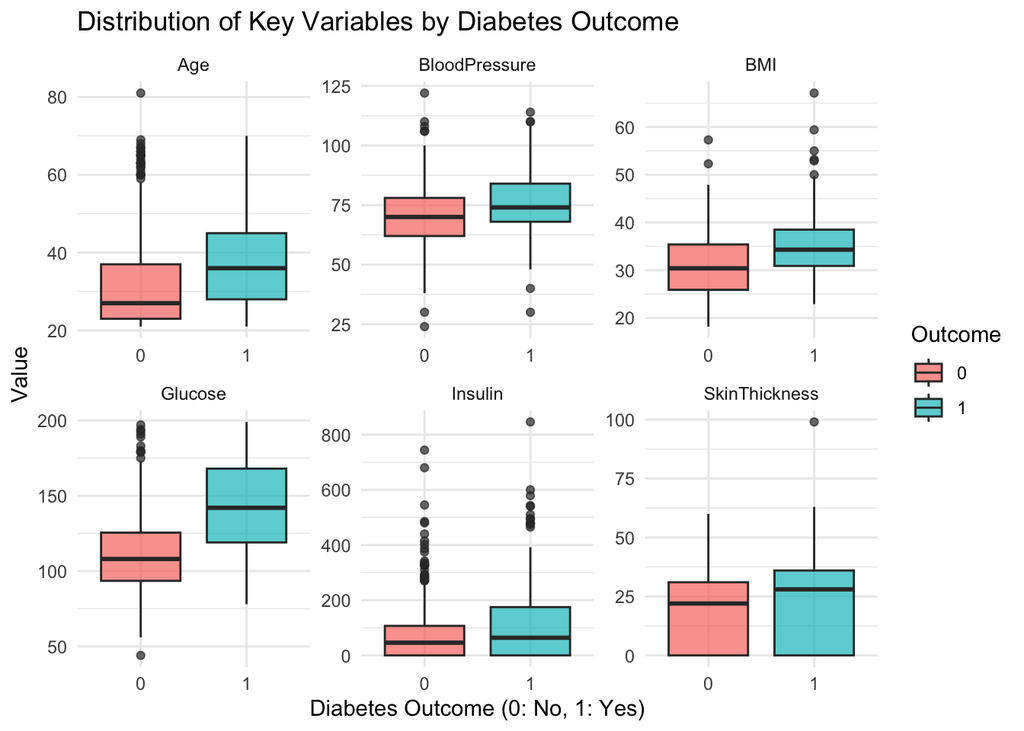

```r
long_data <- clean_diabetes %>%
  select(Glucose, BMI, BloodPressure, Insulin, SkinThickness, Age, Outcome) %>%
  pivot_longer(cols = -Outcome, names_to = "Variable", values_to = "Value")

ggplot(long_data, aes(x = as.factor(Outcome), y = Value, fill = as.factor(Outcome))) +
  geom_boxplot(alpha = 0.7) +
  facet_wrap(~ Variable, scales = "free") +
  theme_minimal() +
  labs(title = "Distribution of Key Variables by Diabetes Outcome",
       x = "Diabetes Outcome (0: No, 1: Yes)", y = "Value", fill = "Outcome")
```

### Boxplot Description

“The boxplot visualizes the distribution of key variables across diabetes outcomes (0: No diabetes, 1: Diabetes). It shows that individuals with diabetes tend to have higher glucose, BMI, and age compared to those without diabetes. Blood pressure, insulin, and skin thickness also exhibit variations between the two groups, but with less pronounced differences.”